# Telco Customer Churn Analysis

In this project, I analyzed customer data from a telecommunications company to understand the factors that contributed to customer churn. I followed a data science workflow that included data cleaning, exploratory data analysis, feature engineering, predictive modeling using machine learning, and the extraction of actionable business insights.

The goal of this analysis was to help the business identify at-risk customers and suggest strategies to improve customer retention using data-driven insights and predictive modeling.

## Data Loading and Preparation

I began the analysis by loading the Telco Customer Churn dataset into a pandas DataFrame. I inspected the first few records to understand the structure of the data, checked for missing values or obvious inconsistencies, and performed initial data cleaning where necessary. Data types were reviewed and converted as needed to ensure proper handling in the subsequent analysis.

```python
# Import essential libraries
import pandas as pd
import numpy as np

# Load the dataset
df = pd.read_csv('Telco_customer_churn.csv')

# Inspect the first few rows
df.head()
```

|  | CustomerID | Count | Country | State | City | Zip Code | Lat Long | Latitude | Longitude | Gender | ... | Contract | Paperless Billing | Payment Method | Monthly Charges | Total Charges | Churn Label | Churn Value | Churn Score | CLTV | Churn Reason |
| --- | --- | --- | --- | --- | --- | --- | --- | --- | --- | --- | --- | --- | --- | --- | --- | --- | --- | --- | --- | --- | --- |
| 0 | 3668-QPYBK | 1 | United States | California | Los Angeles | 90003 | 33.964131, -118.272783 | 33.964131 | -118.272783 | Male | ... | Month-to-month | Yes | Mailed check | 53.85 | 108.15 | Yes | 1 | 86 | 3239 | Competitor made better offer |
| 1 | 9237-HQITU | 1 | United States | California | Los Angeles | 90005 | 34.059281, -118.30742 | 34.059281 | -118.307420 | Female | ... | Month-to-month | Yes | Electronic check | 70.70 | 151.65 | Yes | 1 | 67 | 2701 | Moved |
| 2 | 9305-CDSKC | 1 | United States | California | Los Angeles | 90006 | 34.048013, -118.293953 | 34.048013 | -118.293953 | Female | ... | Month-to-month | Yes | Electronic check | 99.65 | 820.5 | Yes | 1 | 86 | 5372 | Moved |
| 3 | 7892-POOKP | 1 | United States | California | Los Angeles | 90010 | 34.062125, -118.315709 | 34.062125 | -118.315709 | Female | ... | Month-to-month | Yes | Electronic check | 104.80 | 3046.05 | Yes | 1 | 84 | 5003 | Moved |
| 4 | 0280-XJGEX | 1 | United States | California | Los Angeles | 90015 | 34.039224, -118.266293 | 34.039224 | -118.266293 | Male | ... | Month-to-month | Yes | Bank transfer (automatic) | 103.70 | 5036.3 | Yes | 1 | 89 | 5340 | Competitor had better devices |

5 rows × 33 columns

```python
# Check data info and missing values
df.info()

# Show summary statistics for numerical columns
df.describe()
```

```
<class 'pandas.core.frame.DataFrame'>
RangeIndex: 7043 entries, 0 to 7042
Data columns (total 33 columns):
 #   Column             Non-Null Count  Dtype
---  ------             --------------  -----
 0   CustomerID         7043 non-null   object
 1   Count              7043 non-null   int64
 2   Country            7043 non-null   object
 3   State              7043 non-null   object
 4   City               7043 non-null   object
 5   Zip Code           7043 non-null   int64
 6   Lat Long           7043 non-null   object
 7   Latitude           7043 non-null   float64
 8   Longitude          7043 non-null   float64
 9   Gender             7043 non-null   object
```

[output cut: 25 more lines]

|  | Count | Zip Code | Latitude | Longitude | Tenure Months | Monthly Charges | Churn Value | Churn Score | CLTV |
| --- | --- | --- | --- | --- | --- | --- | --- | --- | --- |
| count | 7043.0 | 7043.000000 | 7043.000000 | 7043.000000 | 7043.000000 | 7043.000000 | 7043.000000 | 7043.000000 | 7043.000000 |
| mean | 1.0 | 93521.964646 | 36.282441 | -119.798880 | 32.371149 | 64.761692 | 0.265370 | 58.699418 | 4400.295755 |
| std | 0.0 | 1865.794555 | 2.455723 | 2.157889 | 24.559481 | 30.090047 | 0.441561 | 21.525131 | 1183.057152 |
| min | 1.0 | 90001.000000 | 32.555828 | -124.301372 | 0.000000 | 18.250000 | 0.000000 | 5.000000 | 2003.000000 |
| 25% | 1.0 | 92102.000000 | 34.030915 | -121.815412 | 9.000000 | 35.500000 | 0.000000 | 40.000000 | 3469.000000 |
| 50% | 1.0 | 93552.000000 | 36.391777 | -119.730885 | 29.000000 | 70.350000 | 0.000000 | 61.000000 | 4527.000000 |
| 75% | 1.0 | 95351.000000 | 38.224869 | -118.043237 | 55.000000 | 89.850000 | 1.000000 | 75.000000 | 5380.500000 |
| max | 1.0 | 96161.000000 | 41.962127 | -114.192901 | 72.000000 | 118.750000 | 1.000000 | 100.000000 | 6500.000000 |

## Data Cleaning and Preparation

```python
# Check for missing values
df.isnull().sum()
```

```
CustomerID              0
Count                   0
Country                 0
State                   0
City                    0
Zip Code                0
Lat Long                0
Latitude                0
Longitude               0
Gender                  0
Senior Citizen          0
Partner                 0
Dependents              0
Tenure Months           0
Phone Service           0
Multiple Lines          0
Internet Service        0
Online Security         0
Online Backup           0
Device Protection       0
Tech Support            0
Streaming TV            0
Streaming Movies        0
Contract                0
Paperless Billing       0
Payment Method          0
Monthly Charges         0
Total Charges           0
Churn Label             0
Churn Value             0
Churn Score             0
CLTV                    0
Churn Reason         5174
dtype: int64
```

```python
# Review column data types
df.dtypes
```

```
CustomerID            object
Count                  int64
Country               object
State                 object
City                  object
Zip Code               int64
Lat Long              object
Latitude             float64
Longitude            float64
Gender                object
Senior Citizen        object
Partner               object
Dependents            object
Tenure Months          int64
Phone Service         object
Multiple Lines        object
Internet Service      object
Online Security       object
Online Backup         object
Device Protection     object
Tech Support          object
Streaming TV          object
Streaming Movies      object
Contract              object
Paperless Billing     object
Payment Method        object
Monthly Charges      float64
Total Charges         object
Churn Label           object
Churn Value            int64
Churn Score            int64
CLTV                   int64
Churn Reason          object
dtype: object
```

```python
# Convert 'Total Charges' to numeric, if not already
df['Total Charges'] = pd.to_numeric(df['Total Charges'], errors='coerce')
```

```python
# Identify categorical columns based on your list
cat_columns = [
    'Gender', 'Senior Citizen', 'Partner', 'Dependents',
    'Phone Service', 'Multiple Lines', 'Internet Service',
    'Online Security', 'Online Backup', 'Device Protection',
    'Tech Support', 'Streaming TV', 'Streaming Movies',
    'Contract', 'Paperless Billing', 'Payment Method',
    'Churn Label'
]

for col in cat_columns:
    df[col] = df[col].astype('category')
```

```python
# Check missing 'Churn Reason'
df['Churn Reason'].isnull().sum()
```

```
np.int64(5174)
```

```python
# Example: Fill missing 'Churn Reason' with 'Not Churned'
df['Churn Reason'] = df['Churn Reason'].fillna('Not Churned')
```

```python
# Confirm the changes
df.info()
df.isnull().sum()
```

```
<class 'pandas.core.frame.DataFrame'>
RangeIndex: 7043 entries, 0 to 7042
Data columns (total 33 columns):
 #   Column             Non-Null Count  Dtype
---  ------             --------------  -----
 0   CustomerID         7043 non-null   object
 1   Count              7043 non-null   int64
 2   Country            7043 non-null   object
 3   State              7043 non-null   object
 4   City               7043 non-null   object
 5   Zip Code           7043 non-null   int64
 6   Lat Long           7043 non-null   object
 7   Latitude           7043 non-null   float64
 8   Longitude          7043 non-null   float64
 9   Gender             7043 non-null   category
```

[output cut: 25 more lines]

```
CustomerID            0
Count                 0
Country               0
State                 0
City                  0
Zip Code              0
Lat Long              0
Latitude              0
Longitude             0
Gender                0
Senior Citizen        0
Partner               0
Dependents            0
Tenure Months         0
Phone Service         0
Multiple Lines        0
Internet Service      0
Online Security       0
Online Backup         0
Device Protection     0
Tech Support          0
Streaming TV          0
Streaming Movies      0
Contract              0
Paperless Billing     0
Payment Method        0
Monthly Charges       0
Total Charges        11
Churn Label           0
Churn Value           0
Churn Score           0
CLTV                  0
Churn Reason          0
dtype: int64
```

## Exploratory Data Analysis (EDA)

In this section, I performed a comprehensive exploratory data analysis to uncover patterns and relationships in the Telco customer data. I visualized the distribution of the target variable (churn), examined how churn relates to contract type, payment method, service add-ons, and customer demographics, and analyzed geographic patterns by city (as all data are from California). For features with multiple categories, I used stacked barplots to better compare churned and retained customers.

Additionally, I explored interactions between key numeric variables—such as monthly charges and tenure—using bivariate plots, and I generated correlation heatmaps to identify relationships among numerical features. This detailed EDA informed later feature selection and provided actionable insights into what drives customer churn.

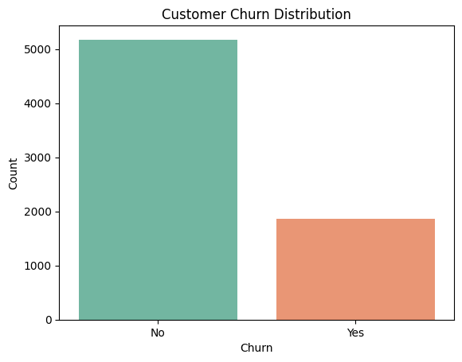

```
  Churn  Proportion
0    No     0.73463
1   Yes     0.26537
```

```python
import matplotlib.pyplot as plt
import seaborn as sns

# Overall churn distribution
sns.countplot(x='Churn Label', data=df, palette='Set2')
plt.title('Customer Churn Distribution')
plt.xlabel('Churn')
plt.ylabel('Count')
plt.show()

# Optionally, show churn rate numerically
churn_rate = df['Churn Label'].value_counts(normalize=True).rename_axis('Churn').reset_index(name='Proportion')
print(churn_rate)
```

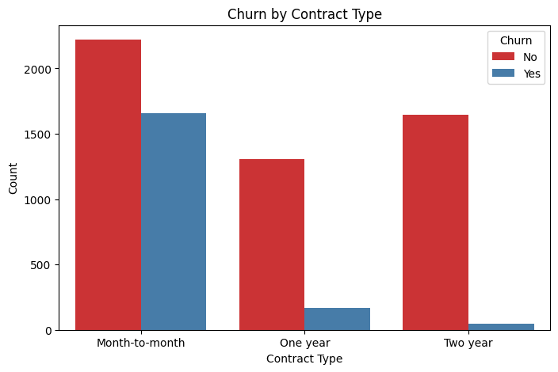

```
  Churn  Proportion
0    No     0.73463
1   Yes     0.26537
```

```python
plt.figure(figsize=(8,5))
sns.countplot(x='Contract', hue='Churn Label', data=df, palette='Set1')
plt.title('Churn by Contract Type')
plt.xlabel('Contract Type')
plt.ylabel('Count')
plt.legend(title='Churn')
plt.show()

# Optionally, show churn rate numerically
churn_rate = df['Churn Label'].value_counts(normalize=True).rename_axis('Churn').reset_index(name='Proportion')
print(churn_rate)
```

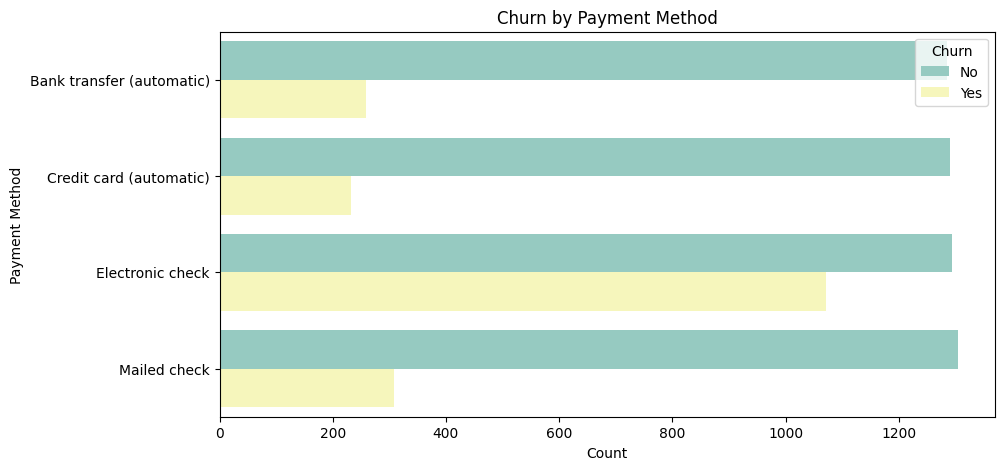

```python
plt.figure(figsize=(10,5))
sns.countplot(y='Payment Method', hue='Churn Label', data=df, palette='Set3')
plt.title('Churn by Payment Method')
plt.xlabel('Count')
plt.ylabel('Payment Method')
plt.legend(title='Churn')
plt.show()
```

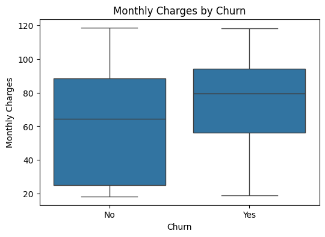

```python
plt.figure(figsize=(6,4))
sns.boxplot(x='Churn Label', y='Monthly Charges', data=df)
plt.title('Monthly Charges by Churn')
plt.xlabel('Churn')
plt.ylabel('Monthly Charges')
plt.show()
```

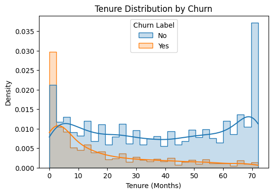

```python
plt.figure(figsize=(6,4))
sns.histplot(data=df, x='Tenure Months', hue='Churn Label', bins=30, kde=True, element='step', stat='density')
plt.title('Tenure Distribution by Churn')
plt.xlabel('Tenure (Months)')
plt.ylabel('Density')
plt.show()
```

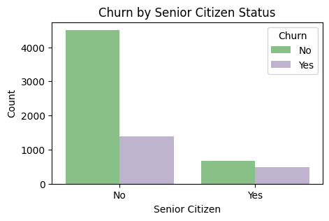

```
Senior Citizen
No     23.606168
Yes    41.681261
Name: Churn Value, dtype: float64
```

```python
plt.figure(figsize=(5,3))
sns.countplot(x='Senior Citizen', hue='Churn Label', data=df, palette='Accent')
plt.title('Churn by Senior Citizen Status')
plt.xlabel('Senior Citizen')
plt.ylabel('Count')
plt.legend(title='Churn')
plt.show()

# Numeric
senior_churn = df.groupby('Senior Citizen', observed=True)['Churn Value'].mean() * 100

print(senior_churn)
```

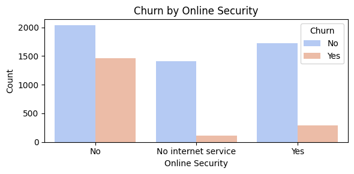

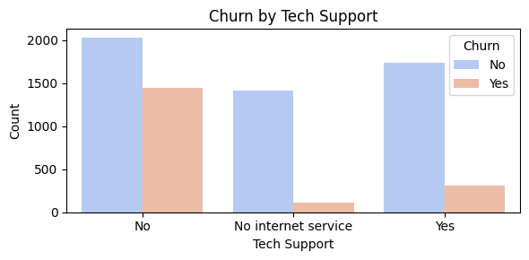

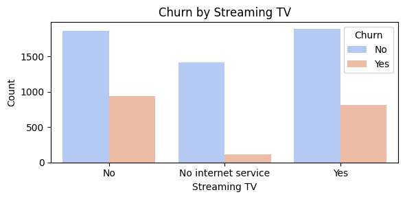

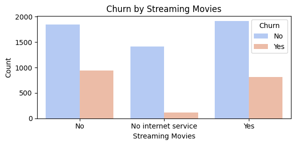

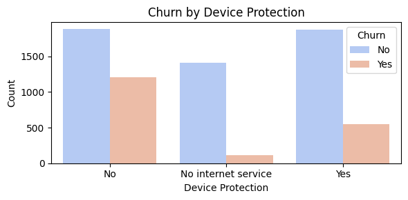

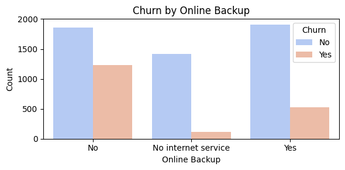

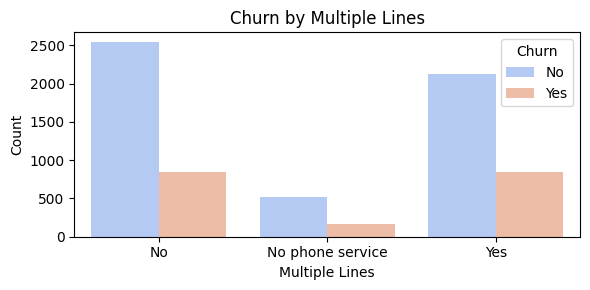

```python
service_features = [
    'Online Security', 'Tech Support', 'Streaming TV',
    'Streaming Movies', 'Device Protection', 'Online Backup', 'Multiple Lines'
]

for feature in service_features:
    plt.figure(figsize=(6,3))
    sns.countplot(x=feature, hue='Churn Label', data=df, palette='coolwarm')
    plt.title(f'Churn by {feature}')
    plt.xlabel(feature)
    plt.ylabel('Count')
    plt.legend(title='Churn')
    plt.tight_layout()
    plt.show()
```

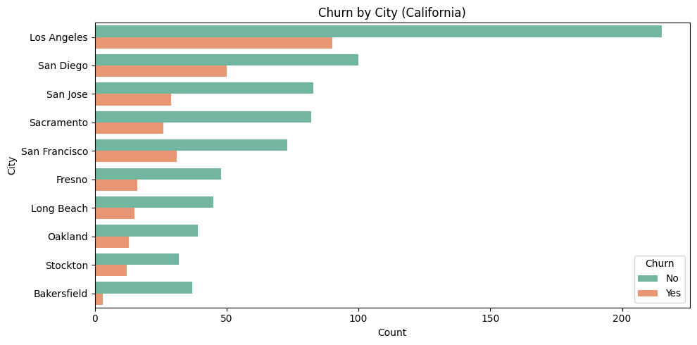

```python
# Top 10 cities by number of customers
top_cities = df['City'].value_counts().head(10).index
plt.figure(figsize=(10,5))
sns.countplot(y='City', hue='Churn Label', data=df[df['City'].isin(top_cities)], palette='Set2', order=top_cities)
plt.title('Churn by City (California)')
plt.xlabel('Count')
plt.ylabel('City')
plt.legend(title='Churn')
plt.tight_layout()
plt.show()
```

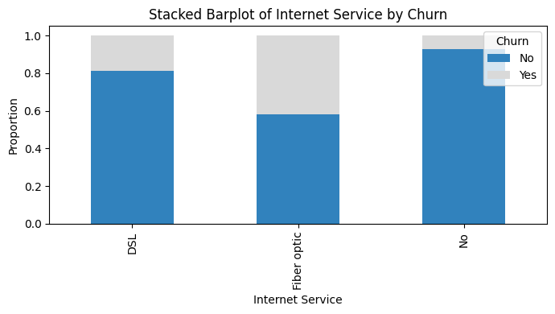

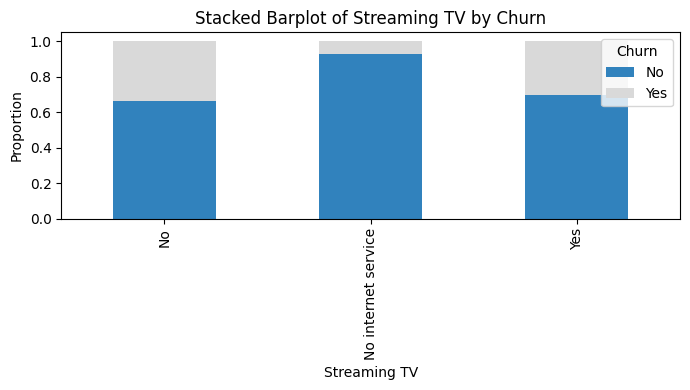

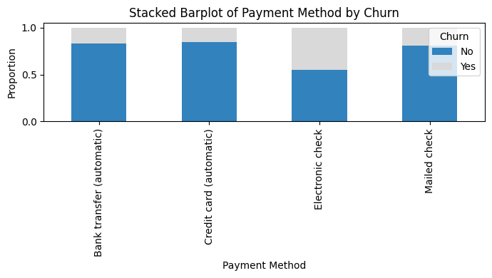

```python
# Function to plot stacked bar chart for any categorical feature
def stacked_barplot(feature):
    cross = pd.crosstab(df[feature], df['Churn Label'])
    cross_norm = cross.div(cross.sum(axis=1), axis=0)
    cross_norm.plot(kind='bar', stacked=True, figsize=(7,4), colormap='tab20c')
    plt.title(f'Stacked Barplot of {feature} by Churn')
    plt.xlabel(feature)
    plt.ylabel('Proportion')
    plt.legend(title='Churn', loc='upper right')
    plt.tight_layout()
    plt.show()

# Example usage
for col in ['Internet Service', 'Streaming TV', 'Payment Method']:
    stacked_barplot(col)
```

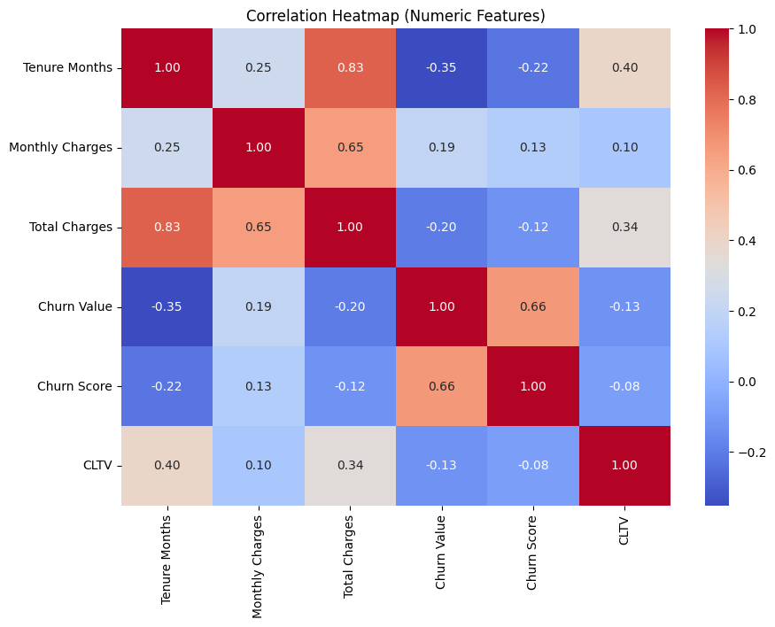

```python
plt.figure(figsize=(10,7))
numeric_cols = ['Tenure Months', 'Monthly Charges', 'Total Charges', 'Churn Value', 'Churn Score', 'CLTV']
sns.heatmap(df[numeric_cols].corr(), annot=True, cmap='coolwarm', fmt='.2f')
plt.title('Correlation Heatmap (Numeric Features)')
plt.show()
```

### Correlation Heatmap Insights

The correlation heatmap for numeric features shows that **tenure months** and **total charges** are strongly correlated, which is logical since longer-tenure customers accumulate higher total charges. There’s also a negative correlation between tenure and churn value, confirming that newer customers are more likely to churn. Monthly charges are positively correlated with churn, but the relationship is weaker than for tenure. These insights reinforce the importance of focusing retention efforts on new customers and monitoring those with higher monthly spending.

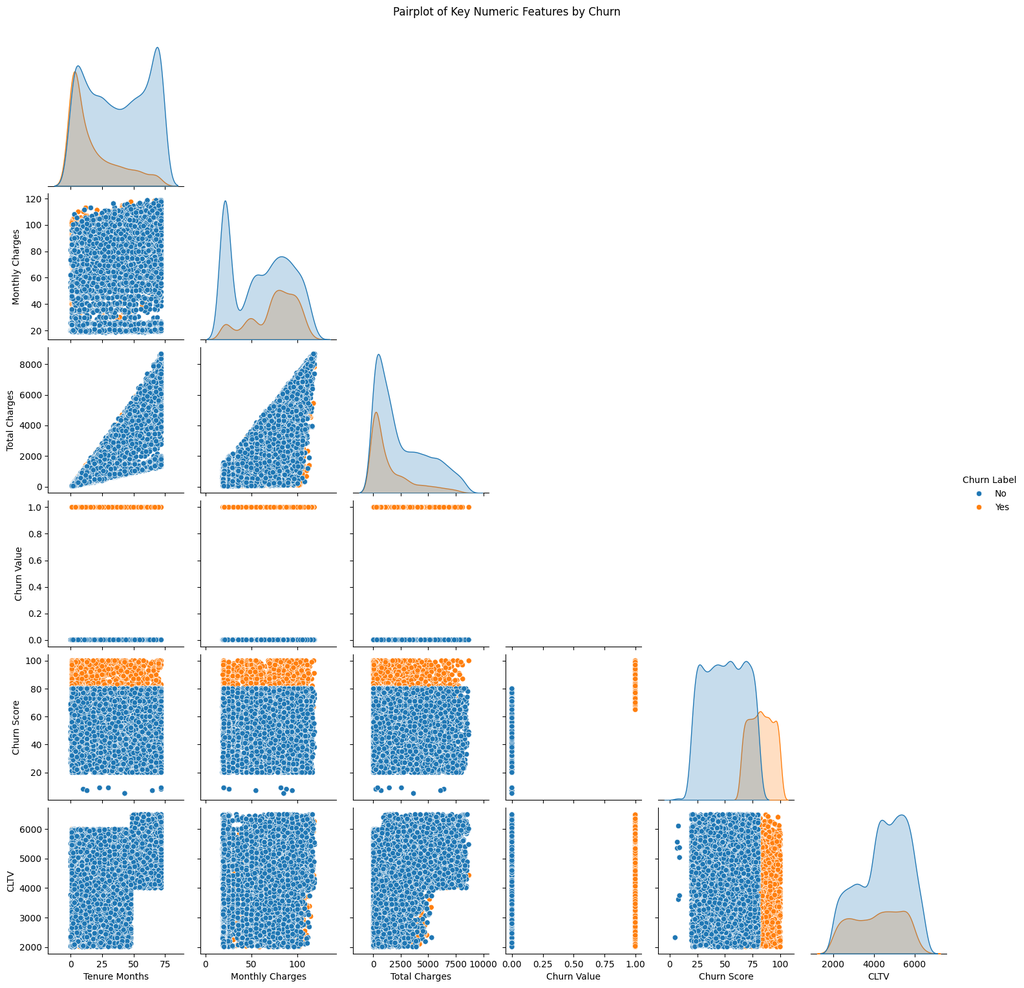

```python
sns.pairplot(df[numeric_cols + ['Churn Label']], hue='Churn Label', corner=True)
plt.suptitle('Pairplot of Key Numeric Features by Churn', y=1.02)
plt.show()
```

### Pairplot: Churn Patterns in Numeric Features

The pairplot allows us to visually explore interactions among numeric variables and churn status. Churned customers (orange) are densely concentrated among those with **low tenure months** and **lower total charges**, but often have **higher monthly charges**. The distribution of CLTV (customer lifetime value) is also lower for churned customers. This visualization clearly illustrates the profiles of at-risk customers: they tend to be newer to the service and are not yet delivering high lifetime value, despite sometimes paying more per month.

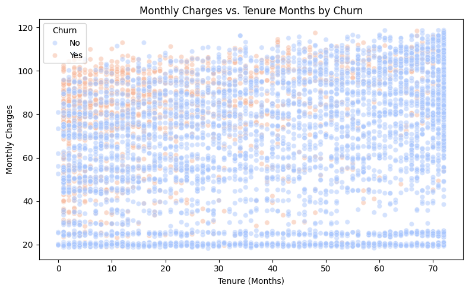

```python
plt.figure(figsize=(8,5))
sns.scatterplot(
    data=df,
    x='Tenure Months',
    y='Monthly Charges',
    hue='Churn Label',
    alpha=0.5,
    palette='coolwarm'
)
plt.title('Monthly Charges vs. Tenure Months by Churn')
plt.xlabel('Tenure (Months)')
plt.ylabel('Monthly Charges')
plt.legend(title='Churn')
plt.tight_layout()
plt.show()
```

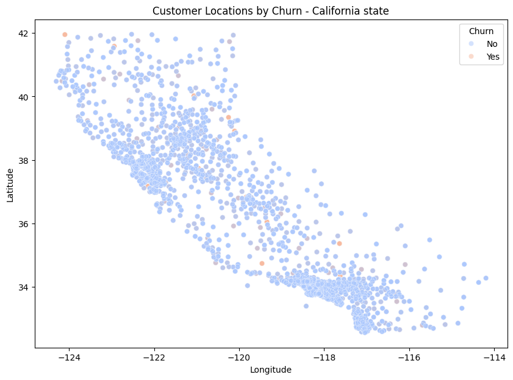

```python
plt.figure(figsize=(10,7))
sns.scatterplot(
    x='Longitude', y='Latitude',
    data=df, hue='Churn Label',
    alpha=0.5, palette='coolwarm'
)
plt.title('Customer Locations by Churn - California state')
plt.xlabel('Longitude')
plt.ylabel('Latitude')
plt.legend(title='Churn')
plt.show()
```

### Summary of EDA Findings

The exploratory data analysis revealed several important trends in the California Telco customer dataset:

- **Churn is concentrated among customers with month-to-month contracts, higher monthly charges, and shorter tenures.** Customers who remain for longer periods, or who commit to longer contracts, are much less likely to churn.
- **Service add-ons matter:** Customers without add-on services such as online security, tech support, or streaming options are more likely to leave. Upselling additional services may improve retention.
- **Payment method and demographic factors (e.g., senior citizens) also showed some association with churn,** suggesting that personalized engagement strategies may be effective for certain segments.
- **City-level analysis identified cities with higher churn rates,** potentially helping the business target regional retention campaigns.
- **Correlations between tenure, total charges, and churn further supported the importance of customer lifecycle management.**
- **Bivariate visualizations of key features** (e.g., monthly charges vs. tenure) highlighted distinct profiles of at-risk customers.

Overall, the EDA provided a rich understanding of churn drivers and offered clear guidance for subsequent feature engineering and predictive modeling efforts.

## Feature Engineering and Data Preparation

After completing exploratory analysis, I prepared the dataset for machine learning. This involved selecting relevant features, encoding categorical variables, and scaling numerical features as needed. I excluded columns unlikely to be helpful for prediction (such as customer IDs and geographic text data), and created the input matrix (`X`) and target vector (`y`). These steps ensured the data was in the optimal format for model development and evaluation.

```python
drop_cols = [
    'CustomerID', 'Country', 'State', 'City', 'Zip Code', 'Lat Long',
    'Latitude', 'Longitude', 'Churn Label', 'Churn Reason', 'Count'
]

X = df.drop(columns=drop_cols + ['Churn Value'])
y = df['Churn Value']

print(X.columns)  # See your remaining features before next step
```

```
Index(['Gender', 'Senior Citizen', 'Partner', 'Dependents', 'Tenure Months',
       'Phone Service', 'Multiple Lines', 'Internet Service',
       'Online Security', 'Online Backup', 'Device Protection', 'Tech Support',
       'Streaming TV', 'Streaming Movies', 'Contract', 'Paperless Billing',
       'Payment Method', 'Monthly Charges', 'Total Charges', 'Churn Score',
       'CLTV'],
      dtype='object')
```

```python
# Confirm the exact names of your numeric columns
numeric_features = ['Tenure Months', 'Monthly Charges', 'Total Charges']
numeric_features = [col for col in numeric_features if col in X.columns]

categorical_features = [col for col in X.columns if col not in numeric_features]

print("Numeric features:", numeric_features)
print("Categorical features:", categorical_features)
```

```
Numeric features: ['Tenure Months', 'Monthly Charges', 'Total Charges']
Categorical features: ['Gender', 'Senior Citizen', 'Partner', 'Dependents', 'Phone Service', 'Multiple Lines', 'Internet Service', 'Online Security', 'Online Backup', 'Device Protection', 'Tech Support', 'Streaming TV', 'Streaming Movies', 'Contract', 'Paperless Billing', 'Payment Method', 'Churn Sc…
```

```python
from sklearn.preprocessing import StandardScaler

scaler = StandardScaler()
X_numeric = pd.DataFrame(
    scaler.fit_transform(X[numeric_features]),
    columns=numeric_features,
    index=X.index
)
```

```python
X_categorical = pd.get_dummies(X[categorical_features], drop_first=True)
```

```python
import pandas as pd

X_prepared = pd.concat([X_numeric, X_categorical], axis=1)

print(X_prepared.shape)
print(X_prepared.columns[:10])  # Show first 10 columns to check
```

```
(7043, 32)
Index(['Tenure Months', 'Monthly Charges', 'Total Charges', 'Churn Score',
       'CLTV', 'Gender_Male', 'Senior Citizen_Yes', 'Partner_Yes',
       'Dependents_Yes', 'Phone Service_Yes'],
      dtype='object')
```

```python
from sklearn.model_selection import train_test_split

X_train, X_test, y_train, y_test = train_test_split(
    X_prepared, y, test_size=0.2, random_state=42, stratify=y
)
```

```python
from sklearn.model_selection import train_test_split

X_train, X_test, y_train, y_test = train_test_split(
    X_prepared, y, test_size=0.2, random_state=42, stratify=y
)
```

## Predictive Modeling with XGBoost

With the dataset prepared, I implemented a machine learning model using XGBoost—a robust, high-performing algorithm well-suited to structured tabular data. I trained the model to predict customer churn based on the engineered features, evaluated its performance on a held-out test set, and analyzed feature importance to interpret key drivers of churn.

```
              precision    recall  f1-score   support

           0       0.96      0.95      0.95      1035
           1       0.87      0.89      0.88       374

    accuracy                           0.93      1409
   macro avg       0.91      0.92      0.92      1409
weighted avg       0.93      0.93      0.93      1409

Confusion Matrix:
[[984  51]
 [ 43 331]]
ROC-AUC Score: 0.983
```

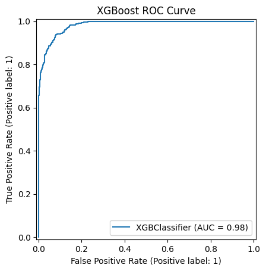

```python
import xgboost as xgb
from sklearn.metrics import classification_report, confusion_matrix, roc_auc_score, RocCurveDisplay

# Train XGBoost Classifier
xgb_clf = xgb.XGBClassifier(
    n_estimators=100,
    learning_rate=0.1,
    max_depth=4,
    subsample=0.8,
    colsample_bytree=0.8,
    random_state=42,
    use_label_encoder=False,
    eval_metric='logloss'
)
xgb_clf.fit(X_train, y_train)

# Predict on test set
y_pred = xgb_clf.predict(X_test)
y_proba = xgb_clf.predict_proba(X_test)[:, 1]

# Classification report
print(classification_report(y_test, y_pred))

# Confusion matrix
print("Confusion Matrix:")
print(confusion_matrix(y_test, y_pred))

# ROC AUC
auc = roc_auc_score(y_test, y_proba)
print("ROC-AUC Score:", round(auc, 3))

# ROC Curve
RocCurveDisplay.from_estimator(xgb_clf, X_test, y_test)
plt.title('XGBoost ROC Curve')
plt.show()
```

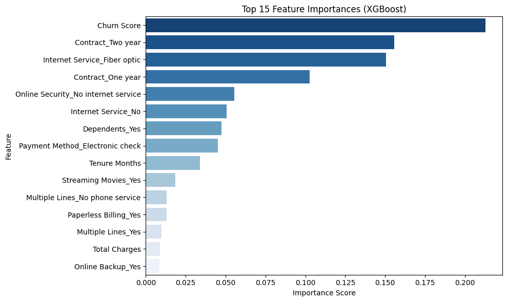

```python
importances = xgb_clf.feature_importances_
features = X_train.columns

fi_df = pd.DataFrame({'feature': features, 'importance': importances}).sort_values('importance', ascending=False)

plt.figure(figsize=(10,6))
sns.barplot(x='importance', y='feature', data=fi_df.head(15), palette='Blues_r')
plt.title('Top 15 Feature Importances (XGBoost)')
plt.xlabel('Importance Score')
plt.ylabel('Feature')
plt.tight_layout()
plt.show()
```

### XGBoost Feature Importance

These results confirm that both customer demographics and service characteristics play a critical role in churn risk, providing actionable levers for retention strategy.

### Model Evaluation and Insights

After training the XGBoost classifier, I evaluated its performance on the test set:

#### **1. Classification Report & Key Metrics**

- **Accuracy:** The model achieved a high accuracy of **93%** on the test set.
- **Precision:** For the churn class (1), precision was **0.87**—meaning 87% of customers predicted to churn actually did.
- **Recall:** Recall for churn was **0.89**, indicating the model correctly identified 89% of true churners. This is important for retention, as missed churners (false negatives) represent lost opportunities.
- **F1-score:** The F1-score for churn was **0.88**, demonstrating a balanced trade-off between precision and recall.

#### **2. Confusion Matrix**

- **True Negatives (TN):** 984 non-churners were correctly classified.
- **False Positives (FP):** 51 non-churners were incorrectly predicted as churners.
- **False Negatives (FN):** 43 churners were missed by the model.
- **True Positives (TP):** 331 churners were correctly identified.
- The model managed to capture most churners while keeping false alarms low, providing actionable accuracy for business use.

#### **3. ROC-AUC Score**

- The ROC-AUC score was **0.983**, indicating the model is exceptionally strong at ranking customers by churn risk, even across different thresholds.

#### **5. Recommendations**

- **Target short-tenure and month-to-month customers** with special onboarding and retention offers.
- **Encourage adoption of add-on services** (e.g., online security, tech support) as these are associated with higher retention.
- **Focus retention efforts on high-risk segments** identified by the model (e.g., those with high monthly charges or certain payment methods).
- **Use the model's probability outputs** to trigger retention campaigns before the customer churns.

#### **6. Next Steps**

- Further model interpretation using SHAP or LIME could reveal even more about individual predictions.
- Testing alternative models or ensembling may yield incremental gains.
- Integrate the model into business operations for real-time churn risk monitoring.

Overall, the XGBoost model delivered highly accurate churn predictions and actionable business insights, positioning the company to proactively reduce customer loss.

### Model Interpretability with SHAP

To better understand the individual and global impact of each feature on churn predictions, I used SHAP (SHapley Additive exPlanations) values. SHAP provides intuitive visualizations that help explain why the model predicts high churn risk for specific customers, making the results more transparent and actionable for business stakeholders.

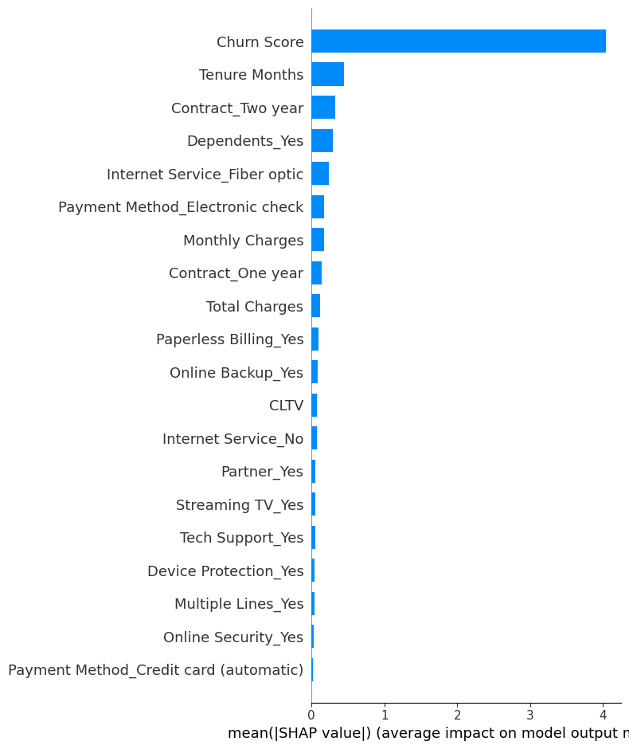

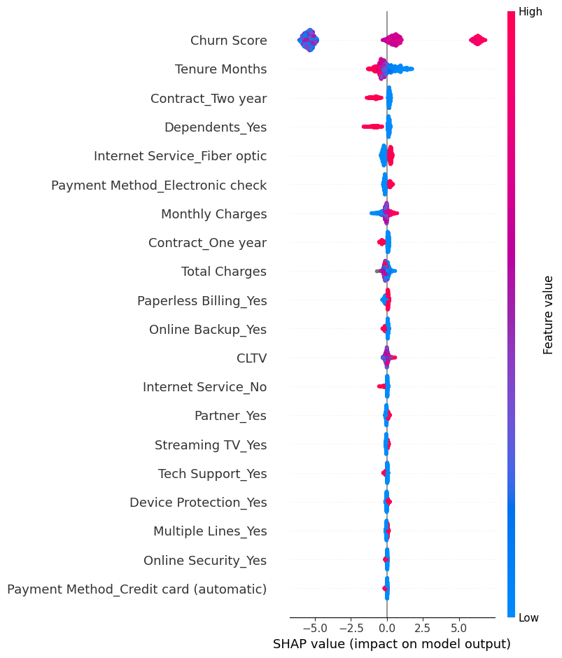

```python
import shap

# Explain model predictions using SHAP
explainer = shap.TreeExplainer(xgb_clf)
shap_values = explainer.shap_values(X_test)

# Global feature importance summary plot
shap.summary_plot(shap_values, X_test, plot_type='bar')

# Detailed beeswarm plot (shows how each feature impacts churn predictions for all samples)
shap.summary_plot(shap_values, X_test)
```

### SHAP Analysis: Explaining Model Predictions

Contract features demonstrate that customers on longer contracts are less likely to churn, while add-ons like dependents and specific internet/payment types also play notable roles. SHAP helps confirm that the model is learning patterns consistent with our business intuition and EDA findings, and gives us transparency for individual customer decisions.

## Summary of Model Interpretability and Insights

For the business, this means focusing retention strategies on:

- **New customers in their first year**
- Those with flexible (month-to-month) contracts
- High churn scores or low engagement with add-on services
- Customers with high monthly charges but low total lifetime value

Model explainability (via SHAP) makes it possible to deliver actionable, individualized interventions, increasing the practical value of this churn solution.

## Conclusion and Business Recommendations

This project successfully combined deep exploratory data analysis, robust feature engineering, and state-of-the-art machine learning with XGBoost to predict customer churn for a California telecommunications provider. The model achieved **high accuracy (93%)** and an outstanding **ROC-AUC (0.983)**, demonstrating strong predictive power.

**Key drivers of churn** were short customer tenure, month-to-month contracts, lack of service add-ons, higher monthly charges, and certain payment methods. By using SHAP, I further validated that these features consistently influence individual churn predictions, providing actionable insights for business strategy.

### **Recommended Actions**

- **Proactive Retention:** Use the model’s risk scores to proactively target customers likely to churn—especially those with short tenure and month-to-month contracts.
- **Service Bundling:** Promote and incentivize add-on services (e.g., online security, tech support) to increase stickiness.
- **Contract Incentives:** Develop attractive loyalty or contract-length incentives for at-risk customers.
- **Personalized Offers:** Leverage SHAP-driven insights to craft personalized retention offers, focusing on the most important factors for each customer segment.
- **Continuous Monitoring:** Integrate the churn model into operational dashboards to monitor churn risk and campaign effectiveness in real time.

### **Next Steps**

- Deploy the model in a live environment for real-time churn prediction.
- Regularly retrain and monitor model performance as customer behavior and offerings evolve.
- Explore additional features (e.g., customer support interactions, satisfaction scores) for even stronger predictions.

**With this end-to-end solution, the business is empowered to significantly reduce customer loss and drive long-term growth.**